# Rolling-window benchmark, redone with cuplyr

### Skipped cells (cuplyr cells that run on the CPU fallback)

These cells were not timed; the reason is the message of the probe call. None of them has a row in `timings.csv` or `correctness.csv`; they are listed in `skipped.csv`.

| chunk | stat | fn | width | reason |
| --- | --- | --- | --- | --- |
| bench-main | median | cuplyr | 11 | cuplyr: mutate() fell back to CPU evaluation for: mutate() |
| bench-main | median | cuplyr | 101 | cuplyr: mutate() fell back to CPU evaluation for: mutate() |
| bench-main | median | cuplyr | 1001 | cuplyr: mutate() fell back to CPU evaluation for: mutate() |

## Threads actually used

Default vs one thread, median ms (IQR) over the samples of each entry (9-20 per cell for the 1e7-row rows, 1 for `frollapply`; 10 for the extension rows), width 101. `ratio` = one-thread median / default median; “scales” says whether the entry used the extra threads (ratio >= 1.5: yes; <= 1.15: no). The `default_threads` column is what the package reports, not what the call used.

| experiment | statistic | entry | default_threads | default_ms | one_thread_ms | ratio | scales |
| --- | --- | --- | --- | --- | --- | --- | --- |
| 1e7 rows, w=101 | mean | data.table | 12 (setDTthreads) | 18.6 (18.3-18.6) | 18.2 (18.1-18.3) | 0.98 | no |
| 1e7 rows, w=101 | sum | data.table | 12 (setDTthreads) | 18.4 (18.2-18.5) | 18.3 (18.2-18.4) | 1.00 | no |
| 1e7 rows, w=101 | min | data.table | 12 (setDTthreads) | 28.1 (28.0-28.2) | 27.9 (27.6-28.0) | 0.99 | no |
| 1e7 rows, w=101 | max | data.table | 12 (setDTthreads) | 27.8 (27.6-28.3) | 27.9 (27.9-28.0) | 1.00 | no |
| 1e7 rows, w=101 | sd | data.table | 12 (setDTthreads) | 115 (113-115) | 113 (112-115) | 0.98 | no |
| 1e7 rows, w=101 | median | data.table | 12 (setDTthreads) | 194 (192-194) | 472 (469-477) | 2.44 | yes (2.4x slower at 1 thread) |
| 1e7 rows, w=101 | sum | data.table (exact) | 12 (setDTthreads) | 60.2 (58.1-61.6) | 390 (387-394) | 6.48 | yes (6.5x slower at 1 thread) |
| 1e7 rows, w=101 | custom | data.table::frollapply | 12 (setDTthreads) | 12900 (12900-12900) | 24000 (24000-24000) | 1.87 | yes (1.9x slower at 1 thread) |
| 1e7 rows, w=101 | mean | RcppRoll | 24 (OpenMP) | 11.6 (11.5-11.7) | 83.7 (81.7-84.5) | 7.22 | yes (7.2x slower at 1 thread) |
| 1e7 rows, w=101 | sum | RcppRoll | 24 (OpenMP) | 11.8 (11.6-11.8) | 83.3 (82.4-83.7) | 7.07 | yes (7.1x slower at 1 thread) |
| 1e7 rows, w=101 | min | RcppRoll | 24 (OpenMP) | 11.8 (11.7-11.9) | 118 (117-119) | 10.05 | yes (10.1x slower at 1 thread) |
| 1e7 rows, w=101 | max | RcppRoll | 24 (OpenMP) | 11.7 (11.6-11.9) | 118 (117-119) | 10.10 | yes (10.1x slower at 1 thread) |
| 1e7 rows, w=101 | sd | RcppRoll | 24 (OpenMP) | 12.1 (11.9-12.3) | 107 (106-109) | 8.88 | yes (8.9x slower at 1 thread) |
| 1e7 rows, w=101 | median | RcppRoll | 24 (OpenMP) | 40.4 (40.4-40.5) | 664 (658-667) | 16.42 | yes (16.4x slower at 1 thread) |
| 1e7 rows, w=101 | mean | roll | 24 (RcppParallel) | 48.8 (48.5-49.3) | 49.2 (48.9-49.4) | 1.01 | no |
| 1e7 rows, w=101 | sum | roll | 24 (RcppParallel) | 40.2 (39.8-40.4) | 40.3 (39.8-40.5) | 1.00 | no |
| 1e7 rows, w=101 | min | roll | 24 (RcppParallel) | 113 (112-115) | 113 (113-115) | 1.00 | no |
| 1e7 rows, w=101 | max | roll | 24 (RcppParallel) | 113 (113-114) | 113 (113-114) | 0.99 | no |
| 1e7 rows, w=101 | sd | roll | 24 (RcppParallel) | 239 (237-241) | 242 (238-243) | 1.01 | no |
| 1e7 rows, w=101 | median | roll | 24 (RcppParallel) | 2030 (2030-2040) | 2030 (2020-2050) | 1.00 | no |
| grouped mean, w=101 | mean | data.table (by = g) | 12 (setDTthreads) | 30.7 (29.5-31.6) | 28.7 (28.6-29.0) | 0.94 | no |
| 1e7 ungrouped mean, w=101 | mean | data.table | 12 (setDTthreads) | 12.6 (12.6-12.7) | 12.6 (12.6-12.7) | 1.00 | no |
| 1e7 ungrouped mean, w=101 | mean | RcppRoll | 24 (OpenMP) | 8.02 (7.95-8.04) | 77.7 (77.2-78.4) | 9.68 | yes (9.7x slower at 1 thread) |
| 1e7 ungrouped mean, w=101 | mean | roll | 24 (RcppParallel) | 39.6 (39.5-39.8) | 40.0 (39.3-40.2) | 1.01 | no |

Reading it:

- RcppRoll scales on every statistic (7.1-16.4x slower at one thread at w=101; 9.7x at 1e7 rows). Its 24-thread numbers are what the “RcppRoll” rows in the tables show.
- data.table scales only for `frollmedian` (2.4x), `frollsum(algo = "exact")` (6.5x) and `frollapply` (1.9x). `frollmean/sum/min/max/sd` (ratio 0.98-1.00) and the grouped `by = g` call (0.94) do not: that is the figure the grouped comparison below depends on.
- roll does not scale on any statistic (ratio 0.99-1.01), including at 1e7 rows.

## Hardware and versions

GPU: NVIDIA GeForce RTX 5070, 12 GB, compute capability 12.0. CPU: 12th Gen Intel(R) Core(TM) i9-12900K, 24 logical cores. R 4.6.1. Library: /home/theo/cuplr/scratchpad/benchmarks/rlib (benchmark packages only); cuplyr loaded with `pkgload::load_all()` from /home/theo/cuplr-wt/_integration.

| package | version | note |
| --- | --- | --- |
| R | 4.6.1 |  |
| cuplyr | 0.1.1.9000 | loaded with pkgload::load_all() from the checkout (dev) |
| data.table | 1.18.4 |  |
| roll | 1.2.1 |  |
| RollingWindow | 0.2 | GitHub master tarball |
| runstats | 1.1.0 | CRAN Archive |
| slider | 0.3.3 |  |
| RcppRoll | 0.4.0 |  |
| zoo | 1.9.1 |  |
| runner | 0.4.6 |  |
| microbenchmark | 1.5.0 |  |
| RcppParallel | 6.2.1 |  |
| dplyr | 1.2.1 |  |
| ggplot2 | 4.0.3 |  |
| scales | 1.4.0 |  |
| patchwork | 1.3.2 |  |
| ggdist | 3.3.3 |  |
| paletteer | 1.7.0 |  |
| ggtext | 0.2.0 | installed but not used: element_markdown() did not render under ggplot2 4.0.3 |
| fftwtools | 0.9.11 | runstats dependency |
| tibble | 3.3.1 | used by the grouped slider entry |
| knitr | 1.51 |  |
| rmarkdown | 2.31 |  |
| Quarto | 1.9.38 |  |
| cudf (libcudf) | 25.12.00 |  |

Thread settings as found: `OMP_NUM_THREADS` unset; `data.table::getDTthreads()` 12; `RcppRoll::roll_threads()` 24; `RcppParallel::defaultNumThreads()` 24.

**Core placement.** This CPU mixes core types (16 logical CPUs at up to 5100 MHz, 8 at up to 3900 MHz), and the benchmark does not pin threads, so a single-threaded call can land on either kind. Chunk `bench-cores` pinned RcppRoll’s one-thread rolling mean (w=101) to each kind in turn: 76.9 ms on a fast core and 141 ms on a slow one, so landing on a slow core can cost a single-threaded call up to 1.8x, which is what pinning shows for this one. Which kind of core each benchmark timing ran on is not recorded. The calls that run on one thread, default-thread rows included, are exposed to this: roll, RollingWindow, slider, zoo, runner and runstats; data.table’s `frollmean/sum/min/max/sd`; the `(1 thread)` controls; and cuplyr’s host-side R work. The calls the threads table shows using more than one thread (RcppRoll; data.table’s `frollmedian`, `frollsum(algo = "exact")` and `frollapply`) can use both kinds of core.

Cross-check of the one-thread RcppRoll mean at w=101: 83.7 ms in the results table, 77.7 ms scaled to 1e7 rows from the 1e7-row run, 76.9 ms on a fast core and 141 ms on a slow one. The table figure agrees with the 1e7-row rate and the fast-core figure within a factor of 1.25 and is 1.68x away from the slow-core figure, so this render’s one-thread RcppRoll cell ran at fast-core speed. data.table’s default and one-thread timings of its single-threaded calls (`frollmean/sum/min/max/sd`) are within 2.0% of each other. The runstats mean call, timed in two chunks of this render, took 120 ms in the results table and 141 ms in chunk `bench-runstats-shift`.

## Install results

Everything the benchmark needs is installed; nothing is “not run: install failed”. It took five install runs because the pixi environment puts a conda gcc first on `PATH`, and that gcc cannot link against the distro R’s `Makeconf` (`-latomic_asneeded` unknown, `__libc_csu_init` missing from the conda sysroot): every package that links Fortran/BLAS (quadprog, RcppArmadillo) or configures TBB (RcppParallel, hence roll) failed in the first runs. `bench/install-deps.R` now:

1. puts `/usr/bin` first on `PATH` and sets `CC/CXX/FC` to the system compilers for the install only (override: `BENCH_PIXI_TOOLCHAIN=1`);
2. points RcppParallel at the distro’s TBB (`TBB_INC`/`TBB_LIB`);
3. installs `fftwtools` (a runstats dependency; tarball installs do not resolve dependencies) and RcppArmadillo before the runstats tarball;
4. builds RollingWindow with a temporary user Makevars that drops `-Werror=format-security` (its generated `RcppExports.cpp` trips it on current Rcpp).

Logs, in order, with the packages whose install failed in each (read from the summary table at the end of each log in /home/theo/cuplr/scratchpad/benchmarks/rolling-1e7):

| log | failed | note |
| --- | --- | --- |
| install-attempt1-pixi-toolchain.log | roll, ggdist, ggtext, runstats, RollingWindow |  |
| install-attempt2-path-only.log | roll, runstats, RollingWindow | PATH only |
| install-attempt3-env.log | roll, runstats, RollingWindow | roll via RcppParallel’s TBB configure, runstats via missing fftwtools, RollingWindow format-security |
| install-attempt4.log | RollingWindow | RollingWindow only: the first flag attempt, PKG_CXXFLAGS, did not override the later -Werror |
| install.log | none | final run |

A single clean run from an empty library was not repeated, so reproducibility from scratch rests on those incremental runs. The installer script’s last edits (the `finally =` that unsets the temporary Makevars variable, and knitr and rmarkdown added to `cran_pkgs`) have not been exercised by an install run: nothing was reinstalled. Base `install.packages()` only; nothing went into the pixi library and cuplyr was not installed. knitr 1.51 and rmarkdown 2.31, which this document needs, are listed in `bench/install-deps.R`; they were found in `/home/theo/R/x86_64-pc-linux-gnu-library/4.6` (not the benchmark library), and rendering this document installs nothing.

## Results: median ms per call at 1e7 rows

Cell format: median (IQR) n=samples. Rows sorted by the width-101 median. `(1 thread)` rows are the single-thread controls. Each statistic’s table is followed by its plot (log10 ms axis, point = median, bars = 50% and 95% of samples, colour = width, width-101 median labelled). The median table and plot carry a note instead of a cuplyr number, because that call is not timed; every cuplyr entry that is timed is computation only.

### mean (median ms (IQR) n=samples)

| function | w=11 | w=101 | w=1001 |
| --- | --- | --- | --- |
| cuplyr | 3.80 (3.78-3.81) n=20 | 6.58 (6.57-6.59) n=20 | 6.54 (6.53-6.56) n=20 |
| cuplyr (froll alias) | 3.80 (3.79-3.81) n=20 | 6.58 (6.57-6.60) n=20 | 6.59 (6.58-6.60) n=20 |
| RcppRoll | 9.49 (9.37-9.56) n=20 | 11.6 (11.5-11.7) n=20 | 11.4 (11.2-11.6) n=20 |
| data.table (1 thread) | 18.7 (18.6-18.7) n=20 | 18.2 (18.1-18.3) n=20 | 18.5 (18.4-18.6) n=20 |
| data.table | 18.5 (18.3-18.7) n=20 | 18.6 (18.3-18.6) n=20 | 18.2 (18.2-18.4) n=20 |
| roll | 49.3 (49.1-49.5) n=20 | 48.8 (48.5-49.3) n=20 | 48.6 (48.3-49.2) n=20 |
| roll (1 thread) | 49.1 (48.9-49.3) n=20 | 49.2 (48.9-49.4) n=20 | 48.6 (48.5-48.9) n=20 |
| RollingWindow | 73.7 (73.2-74.0) n=20 | 74.0 (73.7-74.2) n=20 | 76.0 (75.8-76.6) n=20 |
| RcppRoll (1 thread) | 20.4 (20.1-20.5) n=20 | 83.7 (81.7-84.5) n=20 | 79.1 (79.0-79.3) n=20 |
| runstats | 120 (120-121) n=20 | 120 (119-120) n=20 | 118 (118-119) n=20 |
| slider | 294 (293-294) n=20 | 491 (490-493) n=20 | 767 (761-772) n=20 |
| zoo | 2100 (2090-2100) n=9 | 2070 (2050-2100) n=8 | 2090 (2040-2090) n=9 |
| runner | 4390 (4370-4410) n=4 | 9780 (9780-9780) n=2 | 63400 (63400-63400) n=1 |

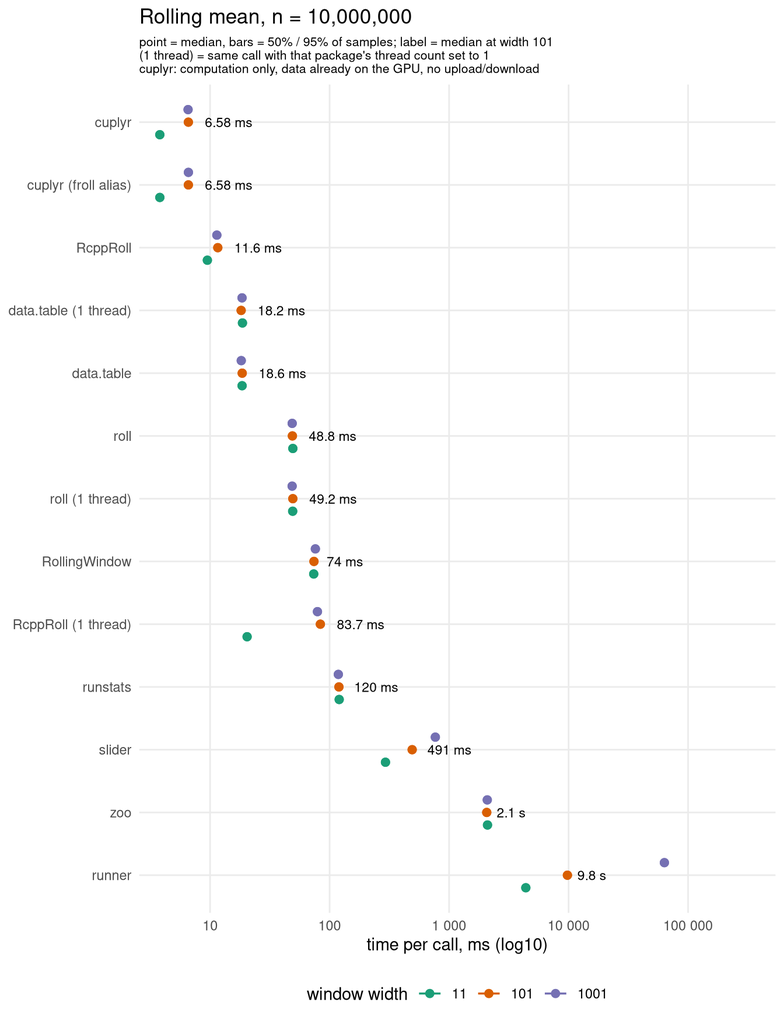

### median (median ms (IQR) n=samples)

| function | w=11 | w=101 | w=1001 |
| --- | --- | --- | --- |
| RcppRoll | 22.8 (22.6-22.9) n=20 | 40.4 (40.4-40.5) n=20 | 55.9 (55.8-56.0) n=20 |
| data.table | 192 (191-194) n=20 | 194 (192-194) n=20 | 205 (204-206) n=20 |
| data.table (1 thread) | 298 (297-300) n=20 | 472 (469-477) n=20 | 673 (662-677) n=20 |
| RollingWindow | 349 (348-354) n=20 | 543 (540-547) n=20 | 684 (680-685) n=20 |
| RcppRoll (1 thread) | 365 (357-368) n=20 | 664 (658-667) n=20 | 957 (952-961) n=20 |
| roll | 1310 (1300-1320) n=15 | 2030 (2030-2040) n=9 | 2540 (2530-2550) n=7 |
| roll (1 thread) | 1310 (1300-1310) n=15 | 2030 (2020-2050) n=10 | 2560 (2550-2570) n=7 |
| zoo | 2230 (2230-2230) n=8 | 2310 (2310-2310) n=8 | 2330 (2320-2330) n=8 |
| cuplyr | not timed: no GPU path (cuplyr’s roll_median() runs on the CPU fallback; cudf 25.12 has no rolling MEDIAN) | not timed | not timed |

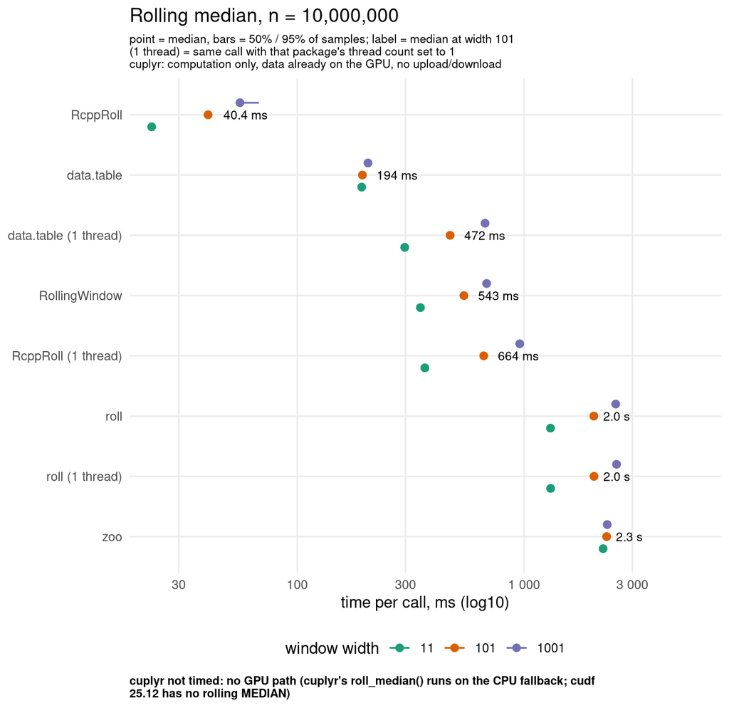

### min (median ms (IQR) n=samples)

| function | w=11 | w=101 | w=1001 |
| --- | --- | --- | --- |
| cuplyr | 3.21 (3.19-3.23) n=20 | 6.24 (6.23-6.25) n=20 | 6.21 (6.21-6.23) n=20 |
| cuplyr (froll alias) | 3.24 (3.23-3.26) n=20 | 6.26 (6.25-6.27) n=20 | 6.25 (6.24-6.27) n=20 |
| RcppRoll | 10.2 (10.2-10.3) n=20 | 11.8 (11.7-11.9) n=20 | 11.8 (11.7-12.0) n=20 |
| data.table (1 thread) | 39.6 (39.5-39.7) n=20 | 27.9 (27.6-28.0) n=20 | 24.1 (24.1-24.3) n=20 |
| data.table | 39.0 (38.9-39.1) n=20 | 28.1 (28.0-28.2) n=20 | 24.5 (24.4-24.6) n=20 |
| roll (1 thread) | 113 (112-115) n=20 | 113 (113-115) n=20 | 113 (112-115) n=20 |
| roll | 115 (113-115) n=20 | 113 (112-115) n=20 | 115 (114-115) n=20 |
| RcppRoll (1 thread) | 40.9 (40.5-41.3) n=20 | 118 (117-119) n=20 | 126 (125-126) n=20 |
| RollingWindow | 179 (178-180) n=20 | 176 (175-177) n=20 | 173 (172-174) n=20 |
| slider | 278 (276-280) n=20 | 536 (532-540) n=20 | 703 (698-707) n=20 |
| runner | 4140 (4120-4160) n=4 | 6890 (6880-6890) n=2 | 32400 (32400-32400) n=1 |

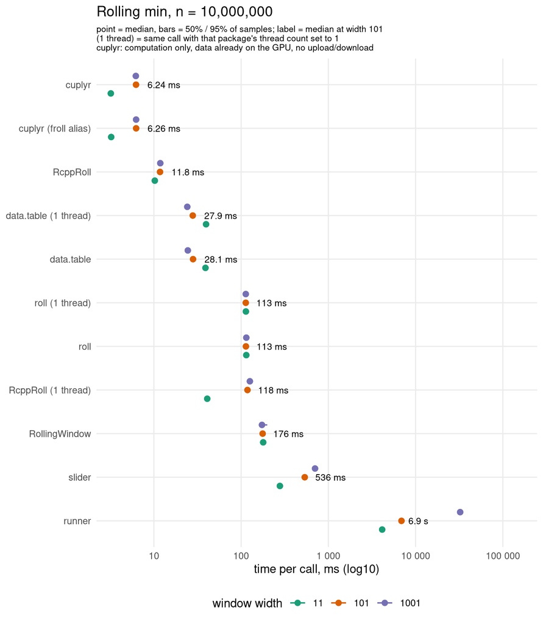

### max (median ms (IQR) n=samples)

| function | w=11 | w=101 | w=1001 |
| --- | --- | --- | --- |
| cuplyr | 3.20 (3.18-3.20) n=20 | 6.24 (6.23-6.25) n=20 | 6.22 (6.21-6.22) n=20 |
| cuplyr (froll alias) | 3.22 (3.21-3.24) n=20 | 6.27 (6.26-6.28) n=20 | 6.27 (6.26-6.28) n=20 |
| RcppRoll | 10.2 (10.1-10.3) n=20 | 11.7 (11.6-11.9) n=20 | 11.9 (11.8-12.0) n=20 |
| data.table | 38.8 (38.7-38.9) n=20 | 27.8 (27.6-28.3) n=20 | 23.9 (23.9-24.2) n=20 |
| data.table (1 thread) | 38.2 (38.1-38.3) n=20 | 27.9 (27.9-28.0) n=20 | 24.3 (24.2-24.5) n=20 |
| roll (1 thread) | 116 (115-116) n=20 | 113 (113-114) n=20 | 113 (113-114) n=20 |
| roll | 116 (115-118) n=20 | 113 (113-114) n=20 | 113 (113-114) n=20 |
| RcppRoll (1 thread) | 41.1 (40.8-41.8) n=20 | 118 (117-119) n=20 | 125 (124-126) n=20 |
| RollingWindow | 174 (173-175) n=20 | 172 (171-173) n=20 | 172 (171-173) n=20 |
| slider | 305 (299-307) n=20 | 548 (545-553) n=20 | 691 (686-697) n=20 |
| zoo | 5650 (5640-5690) n=3 | 5550 (5550-5570) n=3 | 5500 (5470-5510) n=3 |
| runner | 4150 (4130-4180) n=4 | 7030 (7020-7030) n=2 | 34100 (34100-34100) n=1 |

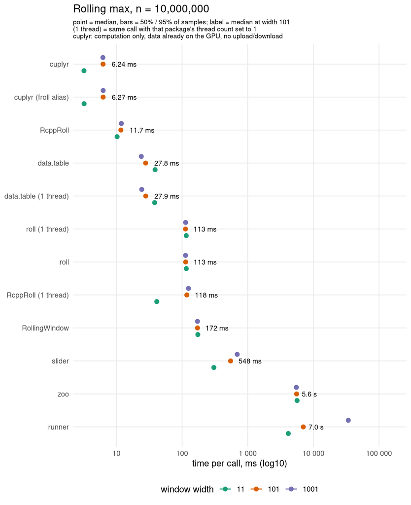

### sum (median ms (IQR) n=samples)

| function | w=11 | w=101 | w=1001 |
| --- | --- | --- | --- |
| cuplyr | 3.37 (3.36-3.38) n=20 | 6.37 (6.34-6.38) n=20 | 6.36 (6.34-6.37) n=20 |
| cuplyr (froll alias) | 3.37 (3.37-3.38) n=20 | 6.40 (6.40-6.43) n=20 | 6.38 (6.37-6.39) n=20 |
| RcppRoll | 9.21 (9.17-9.28) n=20 | 11.8 (11.6-11.8) n=20 | 11.5 (11.4-11.6) n=20 |
| data.table (1 thread) | 18.5 (18.4-18.5) n=20 | 18.3 (18.2-18.4) n=20 | 18.3 (18.2-18.3) n=20 |
| data.table | 18.2 (18.1-18.5) n=20 | 18.4 (18.2-18.5) n=20 | 18.2 (18.1-18.4) n=20 |
| roll | 40.3 (40.1-40.5) n=20 | 40.2 (39.8-40.4) n=20 | 40.4 (40.0-40.8) n=20 |
| roll (1 thread) | 40.1 (39.9-40.3) n=20 | 40.3 (39.8-40.5) n=20 | 40.3 (40.0-40.6) n=20 |
| data.table (exact) | 11.0 (10.9-11.2) n=20 | 60.2 (58.1-61.6) n=20 | 612 (611-613) n=20 |
| RollingWindow | 73.3 (73.0-73.5) n=20 | 72.8 (72.7-73.5) n=20 | 73.3 (72.9-73.6) n=20 |
| RcppRoll (1 thread) | 19.0 (18.7-19.1) n=20 | 83.3 (82.4-83.7) n=20 | 79.6 (78.2-79.9) n=20 |
| data.table (exact, 1 thread) | 54.0 (53.9-54.1) n=20 | 390 (387-394) n=20 | 5690 (5680-5690) n=3 |
| slider | 297 (296-300) n=20 | 489 (486-498) n=20 | 781 (775-781) n=20 |
| zoo | 2050 (2030-2070) n=9 | 2060 (2030-2060) n=9 | 2060 (2030-2060) n=9 |
| runner | 4320 (4310-4350) n=4 | 10200 (10200-10200) n=1 | 67500 (67500-67500) n=1 |

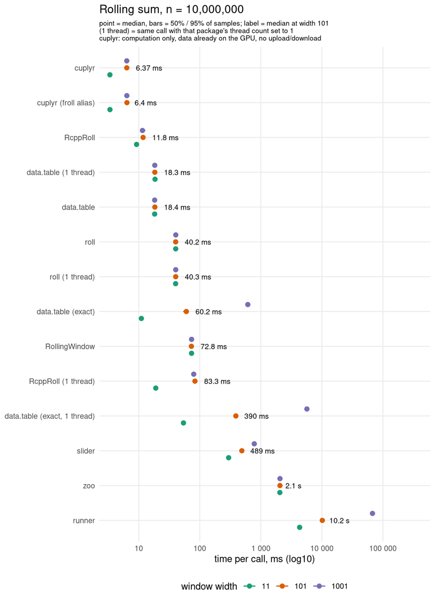

### sd (median ms (IQR) n=samples)

| function | w=11 | w=101 | w=1001 |
| --- | --- | --- | --- |
| cuplyr | 11.7 (11.7-11.7) n=20 | 11.4 (11.4-11.5) n=20 | 11.4 (11.4-11.4) n=20 |
| cuplyr (froll alias) | 11.7 (11.7-11.8) n=20 | 11.5 (11.5-11.5) n=20 | 11.4 (11.4-11.5) n=20 |
| RcppRoll | 13.4 (13.3-13.4) n=20 | 12.1 (11.9-12.3) n=20 | 12.0 (11.9-12.1) n=20 |
| RollingWindow | 93.9 (93.4-94.4) n=20 | 92.0 (91.2-92.9) n=20 | 92.1 (91.4-92.8) n=20 |
| RcppRoll (1 thread) | 107 (106-108) n=20 | 107 (106-109) n=20 | 107 (106-109) n=20 |
| data.table (1 thread) | 113 (113-114) n=20 | 113 (112-115) n=20 | 113 (113-114) n=20 |
| data.table | 115 (113-115) n=20 | 115 (113-115) n=20 | 115 (115-115) n=20 |
| roll | 239 (238-241) n=20 | 239 (237-241) n=20 | 242 (239-244) n=20 |
| roll (1 thread) | 238 (235-241) n=20 | 242 (238-243) n=20 | 237 (236-240) n=20 |
| runstats | 330 (327-374) n=20 | 334 (330-377) n=20 | 330 (327-374) n=20 |

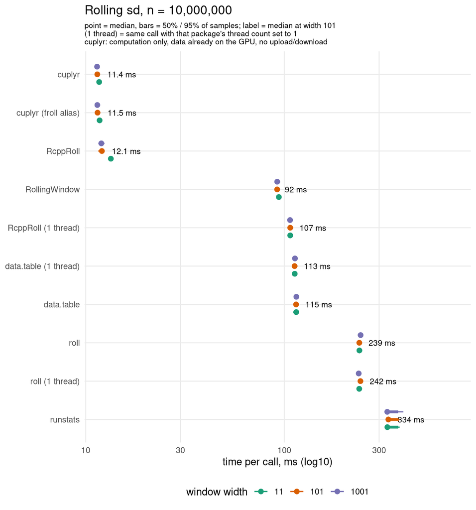

### custom (median ms (IQR) n=samples)

| function | w=11 | w=101 | w=1001 |
| --- | --- | --- | --- |
| data.table::frollapply | 12000 (12000-12000) n=1 | 12900 (12900-12900) n=1 | 13200 (13200-13200) n=1 |
| data.table::frollapply (1 thread) | 24500 (24500-24500) n=1 | 24000 (24000-24000) n=1 | 29700 (29700-29700) n=1 |
| zoo::rollapply | 42700 (42700-42700) n=1 | 56800 (56800-56800) n=1 | 152000 (152000-152000) n=1 |

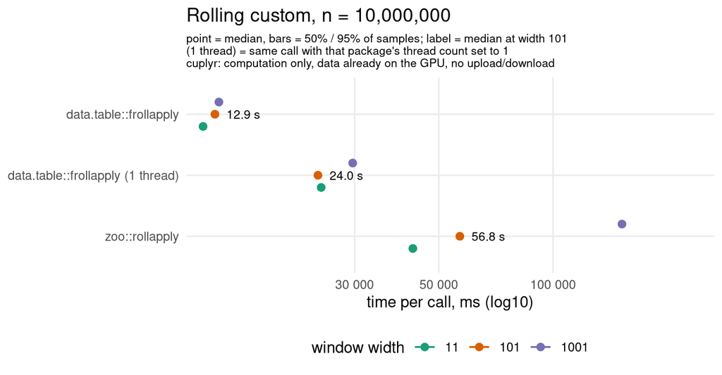

### `times` cuts (every cell not at the configured 20 / 5)

Generated from the `note` column of `timings.csv`. Each cell’s cold probe call is **not recorded**; the samples listed are the timed calls after the warmup.

| stat | fn | width | times | note |
| --- | --- | --- | --- | --- |
| mean | zoo | 11 | 9 | times cut 20 -> 9 (cold probe call 2.2 s, not recorded; 2 untimed warmup call(s); 9 timed call(s), all recorded) |
| mean | runner | 11 | 4 | times cut 20 -> 4 (cold probe call 4.4 s, not recorded; 2 untimed warmup call(s); 4 timed call(s), all recorded) |
| mean | zoo | 101 | 8 | times cut 20 -> 8 (cold probe call 2.2 s, not recorded; 2 untimed warmup call(s); 8 timed call(s), all recorded) |
| mean | runner | 101 | 2 | times cut 20 -> 2 (cold probe call 9.9 s, not recorded; 1 untimed warmup call(s); 2 timed call(s), all recorded) |
| mean | zoo | 1001 | 9 | times cut 20 -> 9 (cold probe call 2.2 s, not recorded; 2 untimed warmup call(s); 9 timed call(s), all recorded) |
| mean | runner | 1001 | 1 | one sample, and it is the cold first call (63 s > 60 s limit); no warmup, no repeat |
| median | roll | 11 | 15 | times cut 20 -> 15 (cold probe call 1.3 s, not recorded; 2 untimed warmup call(s); 15 timed call(s), all recorded) |
| median | roll (1 thread) | 11 | 15 | times cut 20 -> 15 (cold probe call 1.3 s, not recorded; 2 untimed warmup call(s); 15 timed call(s), all recorded) |
| median | zoo | 11 | 8 | times cut 20 -> 8 (cold probe call 2.4 s, not recorded; 2 untimed warmup call(s); 8 timed call(s), all recorded) |
| median | roll | 101 | 9 | times cut 20 -> 9 (cold probe call 2.0 s, not recorded; 2 untimed warmup call(s); 9 timed call(s), all recorded) |
| median | roll (1 thread) | 101 | 10 | times cut 20 -> 10 (cold probe call 2.0 s, not recorded; 2 untimed warmup call(s); 10 timed call(s), all recorded) |
| median | zoo | 101 | 8 | times cut 20 -> 8 (cold probe call 2.4 s, not recorded; 2 untimed warmup call(s); 8 timed call(s), all recorded) |
| median | roll | 1001 | 7 | times cut 20 -> 7 (cold probe call 2.5 s, not recorded; 2 untimed warmup call(s); 7 timed call(s), all recorded) |
| median | roll (1 thread) | 1001 | 7 | times cut 20 -> 7 (cold probe call 2.5 s, not recorded; 2 untimed warmup call(s); 7 timed call(s), all recorded) |
| median | zoo | 1001 | 8 | times cut 20 -> 8 (cold probe call 2.5 s, not recorded; 2 untimed warmup call(s); 8 timed call(s), all recorded) |
| min | runner | 11 | 4 | times cut 20 -> 4 (cold probe call 4.1 s, not recorded; 2 untimed warmup call(s); 4 timed call(s), all recorded) |
| min | runner | 101 | 2 | times cut 20 -> 2 (cold probe call 6.9 s, not recorded; 1 untimed warmup call(s); 2 timed call(s), all recorded) |
| min | runner | 1001 | 1 | times cut 20 -> 1 (cold probe call 32.7 s, not recorded; 0 untimed warmup call(s); 1 timed call(s), all recorded) |
| max | runner | 11 | 4 | times cut 20 -> 4 (cold probe call 4.1 s, not recorded; 2 untimed warmup call(s); 4 timed call(s), all recorded) |
| max | zoo | 11 | 3 | times cut 20 -> 3 (cold probe call 5.8 s, not recorded; 1 untimed warmup call(s); 3 timed call(s), all recorded) |
| max | runner | 101 | 2 | times cut 20 -> 2 (cold probe call 7.0 s, not recorded; 1 untimed warmup call(s); 2 timed call(s), all recorded) |
| max | zoo | 101 | 3 | times cut 20 -> 3 (cold probe call 5.7 s, not recorded; 1 untimed warmup call(s); 3 timed call(s), all recorded) |
| max | runner | 1001 | 1 | times cut 20 -> 1 (cold probe call 34.0 s, not recorded; 0 untimed warmup call(s); 1 timed call(s), all recorded) |
| max | zoo | 1001 | 3 | times cut 20 -> 3 (cold probe call 5.7 s, not recorded; 1 untimed warmup call(s); 3 timed call(s), all recorded) |
| sum | runner | 11 | 4 | times cut 20 -> 4 (cold probe call 4.3 s, not recorded; 2 untimed warmup call(s); 4 timed call(s), all recorded) |
| sum | zoo | 11 | 9 | times cut 20 -> 9 (cold probe call 2.1 s, not recorded; 2 untimed warmup call(s); 9 timed call(s), all recorded) |
| sum | runner | 101 | 1 | times cut 20 -> 1 (cold probe call 10.2 s, not recorded; 1 untimed warmup call(s); 1 timed call(s), all recorded) |
| sum | zoo | 101 | 9 | times cut 20 -> 9 (cold probe call 2.2 s, not recorded; 2 untimed warmup call(s); 9 timed call(s), all recorded) |
| sum | data.table (exact, 1 thread) | 1001 | 3 | times cut 20 -> 3 (cold probe call 5.7 s, not recorded; 1 untimed warmup call(s); 3 timed call(s), all recorded) |
| sum | runner | 1001 | 1 | one sample, and it is the cold first call (67 s > 60 s limit); no warmup, no repeat |
| sum | zoo | 1001 | 9 | times cut 20 -> 9 (cold probe call 2.2 s, not recorded; 2 untimed warmup call(s); 9 timed call(s), all recorded) |
| custom | data.table::frollapply | 11 | 1 | times cut 5 -> 1 (cold probe call 14.4 s, not recorded; 1 untimed warmup call(s); 1 timed call(s), all recorded) |
| custom | data.table::frollapply (1 thread) | 11 | 1 | times cut 5 -> 1 (cold probe call 24.0 s, not recorded; 0 untimed warmup call(s); 1 timed call(s), all recorded) |
| custom | zoo::rollapply | 11 | 1 | times cut 5 -> 1 (cold probe call 47.1 s, not recorded; 0 untimed warmup call(s); 1 timed call(s), all recorded) |
| custom | data.table::frollapply | 101 | 1 | times cut 5 -> 1 (cold probe call 12.7 s, not recorded; 1 untimed warmup call(s); 1 timed call(s), all recorded) |
| custom | data.table::frollapply (1 thread) | 101 | 1 | times cut 5 -> 1 (cold probe call 24.9 s, not recorded; 0 untimed warmup call(s); 1 timed call(s), all recorded) |
| custom | zoo::rollapply | 101 | 1 | times cut 5 -> 1 (cold probe call 59.7 s, not recorded; 0 untimed warmup call(s); 1 timed call(s), all recorded) |
| custom | data.table::frollapply | 1001 | 1 | times cut 5 -> 1 (cold probe call 13.1 s, not recorded; 1 untimed warmup call(s); 1 timed call(s), all recorded) |
| custom | data.table::frollapply (1 thread) | 1001 | 1 | times cut 5 -> 1 (cold probe call 30.6 s, not recorded; 0 untimed warmup call(s); 1 timed call(s), all recorded) |
| custom | zoo::rollapply | 1001 | 1 | one sample, and it is the cold first call (152 s > 60 s limit); no warmup, no repeat |

40 of the 213 cells were cut; everything else ran the full number of samples (20 for the statistics, 5 for the custom functions).

## Correctness

Every timed (statistic x function x width) cell, including every timed cuplyr entry and every one-thread control, was compared with data.table’s result. Reference: `frollmean/frollmedian/frollmin/frollmax/frollsum/frollsd`, and `frollsum` for the custom sum.

213 of 213 (function x width) cells match data.table (all.equal tol 1e-08, same NA positions). The denominator counts the cells that were timed. Three planned cells were skipped as CPU fallbacks and are neither timed nor checked, so the count is 213, not 216.

No cuplyr mismatch, and none for any other package. “Match” includes the leading `NA` padding after normalization (runstats after the right-alignment shift in `rw_normalize()`); a padding or sd-convention difference would have shown up as a mismatch. Not covered: data with `NA`s, `na.rm = TRUE`, non-default alignment.

## Extension: where the GPU should help

Rolling mean, 10 samples per cell (no cuts). `peak_gpu_MB` is the peak from `cuplyr:::gpu_alloc_tracking()` around one untimed call; `held_after_MB` is what was still held when that call returned (see F1). `correct` compares with data.table’s output. All cuplyr numbers here are computation only, data already on the GPU.

Two experiments: (a) grouped: 1e6 rows, 1e3 interleaved groups, w = 101; (b) ungrouped: 1e7 rows, w = 11 / 101 / 1001.

| experiment | fn | width | n_rows | median_ms | IQR | times | peak_gpu_MB | held_after_MB | correct | note |
| --- | --- | --- | --- | --- | --- | --- | --- | --- | --- | --- |
| grouped mean | cuplyr | 101 | 1e6 | 2.58 | 2.57-2.60 | 10 | 36 | 8 | TRUE |  |
| grouped mean | data.table (by = g) | 101 | 1e6 | 30.7 | 29.5-31.6 | 10 |  |  | TRUE |  |
| grouped mean | data.table (by = g, 1 thread) | 101 | 1e6 | 28.7 | 28.6-29.0 | 10 |  |  | TRUE |  |
| grouped mean | slider (grouped_df) | 101 | 1e6 | 56.0 | 55.9-56.0 | 10 |  |  | TRUE |  |
| 1e7 ungrouped mean | cuplyr | 11 | 1e7 | 3.83 | 3.81-3.84 | 10 | 241 | 81 | TRUE |  |
| 1e7 ungrouped mean | data.table | 11 | 1e7 | 13.0 | 12.7-13.0 | 10 |  |  | TRUE |  |
| 1e7 ungrouped mean | data.table (1 thread) | 11 | 1e7 | 13.2 | 13.0-13.2 | 10 |  |  | TRUE |  |
| 1e7 ungrouped mean | roll | 11 | 1e7 | 40.0 | 39.7-40.3 | 10 |  |  | TRUE |  |
| 1e7 ungrouped mean | roll (1 thread) | 11 | 1e7 | 39.8 | 39.7-40.1 | 10 |  |  | TRUE |  |
| 1e7 ungrouped mean | RcppRoll | 11 | 1e7 | 7.38 | 7.35-7.40 | 10 |  |  | TRUE |  |
| 1e7 ungrouped mean | RcppRoll (1 thread) | 11 | 1e7 | 14.7 | 14.6-14.7 | 10 |  |  | TRUE |  |
| 1e7 ungrouped mean | cuplyr | 101 | 1e7 | 6.60 | 6.59-6.62 | 10 | 530 | 81 | TRUE |  |
| 1e7 ungrouped mean | data.table | 101 | 1e7 | 12.6 | 12.6-12.7 | 10 |  |  | TRUE |  |
| 1e7 ungrouped mean | data.table (1 thread) | 101 | 1e7 | 12.6 | 12.6-12.7 | 10 |  |  | TRUE |  |
| 1e7 ungrouped mean | roll | 101 | 1e7 | 39.6 | 39.5-39.8 | 10 |  |  | TRUE |  |
| 1e7 ungrouped mean | roll (1 thread) | 101 | 1e7 | 40.0 | 39.3-40.2 | 10 |  |  | TRUE |  |
| 1e7 ungrouped mean | RcppRoll | 101 | 1e7 | 8.02 | 7.95-8.04 | 10 |  |  | TRUE |  |
| 1e7 ungrouped mean | RcppRoll (1 thread) | 101 | 1e7 | 77.7 | 77.2-78.4 | 10 |  |  | TRUE |  |
| 1e7 ungrouped mean | cuplyr | 1001 | 1e7 | 6.58 | 6.56-6.61 | 10 | 530 | 81 | TRUE |  |
| 1e7 ungrouped mean | data.table | 1001 | 1e7 | 12.8 | 12.7-12.9 | 10 |  |  | TRUE |  |
| 1e7 ungrouped mean | data.table (1 thread) | 1001 | 1e7 | 12.8 | 12.7-12.9 | 10 |  |  | TRUE |  |
| 1e7 ungrouped mean | roll | 1001 | 1e7 | 39.3 | 39.2-39.8 | 10 |  |  | TRUE |  |
| 1e7 ungrouped mean | roll (1 thread) | 1001 | 1e7 | 39.9 | 39.8-40.1 | 10 |  |  | TRUE |  |
| 1e7 ungrouped mean | RcppRoll | 1001 | 1e7 | 8.07 | 8.01-8.33 | 10 |  |  | TRUE |  |
| 1e7 ungrouped mean | RcppRoll (1 thread) | 1001 | 1e7 | 72.2 | 71.9-73.1 | 10 |  |  | TRUE |  |

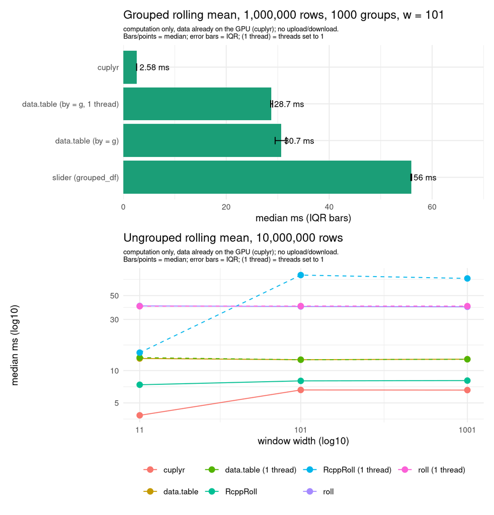

cuplyr grouped is `group_by(tbl_gpu(df), g)` built outside timing, then `compute(mutate(gtg, r = roll_mean(x, n)))` plus the fence, with n the grouped width (101). data.table is `dt[, r := frollmean(x, n), by = g]`, timed at the default thread setting and with `setDTthreads(1)`: **28.7 ms at one thread vs 30.7 ms by default, so its `by=` evaluation ran effectively single-threaded (it did not use the extra threads)**. slider is a grouped_df `mutate(r = slider::slide_mean(x, before = n - 1, complete = TRUE))`.

## Per-call cost breakdown (overhead)

Measured on the same harness as everything else (gc-separated, fenced, `compute()` of an eager `mutate()`), on a 1e3-row table (kernel negligible; 50 samples) and, for contrast, on the 1e7-row table (20 samples). The per-statistic 1e3-row rolling floors are listed too.

| call | rows | median_ms_iqr | min_max_ms | n |
| --- | --- | --- | --- | --- |
| cuplyr (1e3-row overhead floor) [max] | 1,000 | 1.99 (1.97-2.00) | 1.93-2.05 | 50 |
| cuplyr (1e3-row overhead floor) [mean] | 1,000 | 2.05 (2.04-2.05) | 2.01-2.11 | 50 |
| cuplyr (1e3-row overhead floor) [min] | 1,000 | 2.00 (1.98-2.07) | 1.95-2.52 | 50 |
| cuplyr (1e3-row overhead floor) [sd] | 1,000 | 2.30 (2.29-2.33) | 2.24-2.42 | 50 |
| cuplyr (1e3-row overhead floor) [sum] | 1,000 | 2.04 (2.03-2.08) | 2.01-2.19 | 50 |
| plain mutate(y = x + 1) | 1,000 | 1.10 (1.09-1.11) | 1.08-1.19 | 50 |
| window mutate(r = cumsum(x)) | 1,000 | 1.73 (1.72-1.74) | 1.71-1.86 | 50 |
| window mutate(r = roll_mean(x, 101)) | 1,000 | 2.04 (2.02-2.06) | 1.99-2.11 | 50 |
| plain mutate(y = x + 1) | 10,000,000 | 1.39 (1.38-1.39) | 1.37-1.49 | 20 |
| window mutate(r = cumsum(x)) | 10,000,000 | 3.10 (3.09-3.11) | 3.08-3.15 | 20 |
| window mutate(r = roll_mean(x, 101)) | 10,000,000 | 6.59 (6.58-6.60) | 6.57-6.64 | 20 |

- **The about-2.0 ms floor is for window-function mutates; a plain mutate is about 1.1 ms.** At 1e3 rows: plain `mutate(y = x + 1)` 1.10 ms, `mutate(r = cumsum(x))` 1.73 ms, `mutate(r = roll_mean(x, n))` 2.04 ms (the five rolling statistics: 1.99-2.30 ms medians; all 250 samples between 1.93 and 2.52 ms). cumsum and roll_mean differ here (1.73 vs 2.04 ms), so part of the extra 0.9 ms may belong to the kernel rather than to the window-function path.
- **What the path does (read from the code, confirmed with `show_query()`).** A plain mutate is one node (`ast_mutate <- ast_source`). An eager window mutate is `ast_select <- ast_mutate <- ast_window <- ast_source` (`R/mutate.R` lines 641, 645 and 655 push the window, mutate and select nodes), and an eager call runs that chain as one execution (`push_chain()` in `R/execute.R`, F57): the nodes’ outputs share the input table’s columns instead of deep-copying them (`src/ops_window.cpp` about line 1205 passes the input columns through as shared pointers), so only the computed columns are allocated. Before F57 each node built a full table and `x` was copied three times per call. The per-node R work (node build, schema inference) is still done three times; I did not profile where the 0.9 ms goes at 1e3 rows. **GPU memory shows it, though not to the byte** (1e7 rows, `memory-breakdown.csv`; the decomposition below differs from the measured total by 483,750,144 B):

| call | n_rows | x_column_bytes | allocated_bytes | held_after_call_bytes | peak_bytes | held_after_gc_bytes |
| --- | --- | --- | --- | --- | --- | --- |
| window mutate(r = roll_mean(x, 101)) | 10,000,000 | 80,000,000 | 893,122,100 | 81,250,048 | 530,000,054 | 81,250,048 |
| plain mutate(y = x + 1) | 10,000,000 | 80,000,000 | 80,000,220 | 80,000,000 | 80,000,220 | 80,000,000 |
| window mutate(r = cumsum(x)) | 10,000,000 | 80,000,000 | 280,103,264 | 80,000,000 | 280,000,004 | 80,000,000 |